# Python Finals Project: Business Finance (Real Estate Economics)

Group Members: Pamesa, Dawn Andrei - Leader, Porras, Rogelio, Viaña, Justine

## The Business Case: Pandemic Flight & The WFH Shift

In 2020–2022, the sudden rise of remote work severely disrupted standard property valuations. Homebuyers were forced to make a financial choice: pay an astronomical "location premium" for a tiny condo close to central business districts, or move out to the provinces to secure massive space for a fraction of the cost.

Using web-scraped Lamudi real estate data from this exact era, this notebook performs Exploratory Data Analysis (EDA) to historically analyze and quantify this economic shift.

## 1. Handling Custom Text-Based Missing Values

### Objective

```python
import pandas as pd
import numpy as np
import matplotlib.pyplot as plt
import seaborn as sns

def parse_line_right_to_left(line):
    line = line.strip()
    if not line:
        return None
    if line.startswith('\uFEFF'):
        line = line[1:]
    if line.startswith('"') and line.endswith('"'):
        line = line[1:-1]

    try:
        def split_right(s):
            parts = s.rsplit(',', 1)
            return parts[0], parts[1] if len(parts) == 2 else parts[0]

        remaining, link = split_right(line)
        remaining, longitude = split_right(remaining)
        remaining, latitude = split_right(remaining)
        remaining, land_area = split_right(remaining)
        remaining, floor_area = split_right(remaining)
        remaining, bath = split_right(remaining)
        remaining, bedrooms = split_right(remaining)

        # Price (PHP)
        if remaining.endswith('""'):
            idx = remaining.rfind(',""')
            price = remaining[idx+3:-2]
            remaining = remaining[:idx]
        else:
            remaining, price = split_right(remaining)

        # Location
        if remaining.endswith('""'):
            idx = remaining.rfind(',""')
            location = remaining[idx+3:-2]
            remaining = remaining[:idx]
        else:
            remaining, location = split_right(remaining)

        description = remaining
        row = [description, location, price, bedrooms, bath, floor_area, land_area, latitude, longitude, link]
        return [x.replace('""', '"') for x in row]
    except Exception:
        return None

# 1. Load: Open and parse lines using custom right-to-left splitter
with open('PH_houses_v2.csv', 'r', encoding='utf-8') as f:
    rows = [parse_line_right_to_left(line) for line in f]
    rows = [r for r in rows if r is not None]

# 2. Build the DataFrame (Header is the first row)
df = pd.DataFrame(rows[1:], columns=rows[0])

# 3. Clean: Remove quotes/commas and convert to numeric types
df['Price (PHP)'] = pd.to_numeric(df['Price (PHP)'].str.replace('"', '').str.replace(',', ''), errors='coerce')
df['Bedrooms'] = pd.to_numeric(df['Bedrooms'], errors='coerce').fillna(0).astype(int)
df['Bath'] = pd.to_numeric(df['Bath'], errors='coerce').fillna(0).astype(int)

# 4. Filter: Drop rows where critical data is missing
df.dropna(subset=['Price (PHP)', 'Bedrooms', 'Bath', 'Location'], inplace=True)

# 5. Engineering: Create 'Region' category
ncr = ['manila', 'quezon', 'makati', 'pasig', 'taguig', 'mandaluyong', 'pasay', 'paranaque', 'muntinlupa', 'las pinas', 'valenzuela', 'caloocan', 'navotas', 'malabon', 'marikina', 'san juan', 'pateros']
df['Region'] = df['Location'].apply(lambda x: 'Metro Manila' if any(city in str(x).lower() for city in ncr) else 'Provincial')

print(f"Data successfully cleaned. Current shape: {df.shape}")
display(df.head())
```

```
Data successfully cleaned. Current shape: (1460, 11)
```

|  | Description | Location | Price (PHP) | Bedrooms | Bath | Floor_area (sqm) | Land_area (sqm) | Latitude | Longitude | Link | Region |
| --- | --- | --- | --- | --- | --- | --- | --- | --- | --- | --- | --- |
| 0 | 2-Bedroom Unit for Sale in Amisa Private Resid... | Mactan, Lapu-Lapu | 15916180.0 | 2 | 2 | 74 | na | 10.3051555 | 124.0112408 | https://www.lamudi.com.ph/2-bedroom-unit-for-s... | Provincial |
| 1 | 1-Bedroom Unit for Sale in Amisa Private Resid... | Mactan, Lapu-Lapu | 8730355.0 | 1 | 1 | 41 | na | 10.3051555 | 124.0112408 | https://www.lamudi.com.ph/1-bedroom-unit-for-s... | Provincial |
| 2 | Offices at The Galleon - Prime Unit (11G) for ... | San Antonio, Pasig | 27448000.0 | 0 | 0 | 82 | na | 14.588716 | 121.060009 | https://www.lamudi.com.ph/offices-at-the-galle... | Metro Manila |
| 3 | 1-Bedroom Unit (821) for Sale in Maple at Verd... | Ugong, Pasig | 16011000.0 | 1 | 0 | 58 | na | 14.588882 | 121.079016 | https://www.lamudi.com.ph/1-bedroom-unit-821-f... | Metro Manila |
| 4 | Alice 2 Storey Townhouse For Sale in Lancaster... | Tapia, General Trias | 1935600.0 | 3 | 0 | 40 | 40 | 14.35507 | 120.876425 | https://www.lamudi.com.ph/alice-2-storey-townh... | Provincial |

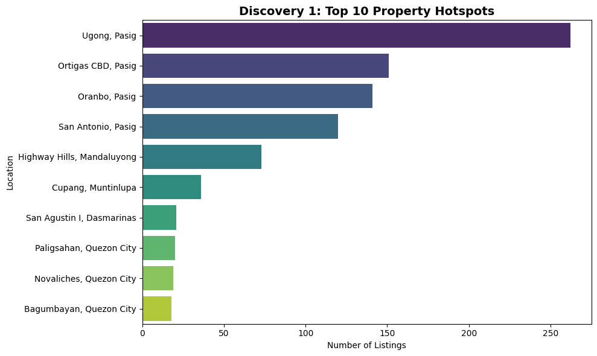

```python
# Discovery 1: Top 10 Property Hotspots
plt.figure(figsize=(10, 6))
top_locs = df['Location'].value_counts().head(10)
sns.barplot(x=top_locs.values, y=top_locs.index, palette="viridis")
plt.title('Discovery 1: Top 10 Property Hotspots', fontsize=14, fontweight='bold')
plt.xlabel('Number of Listings')
plt.ylabel('Location')
plt.tight_layout()
plt.show()
```

```python
from google.colab import drive
drive.mount('/content/drive')
```

## Discovery 1: Additional Regression Analyses (Distance & Infrastructure)

### Background

To mathematically validate the Flocking Theory and evaluate the impact of urban infrastructure on property listing volumes, we conduct secondary linear regression analyses. We look at the correlation of listing volumes against:

1. Distance to BGC (Bonifacio Global City)
2. Distance to the nearest rail transit station
3. Number of major roads serving the area

```python
# %% Data
# area: (distance_to_bgc_km, distance_to_station_km, major_roads, actual_listings)
data = {
    "Ugong":          (7.94, 1.56, 4, 260),
    "Ortigas CBD":    (7.20, 0.55, 4, 150),
    "Oranbo":         (6.82, 1.45, 3, 140),
    "San Antonio":    (7.20, 0.77, 3, 120),
    "Highway Hills":  (6.28, 0.36, 3, 72),
    "Cupang":         (10.39, 5.15, 3, 35),
    "San Agustin I":  (26.46, 14.67, 2, 20),
    "Paligsahan":     (11.58, 2.17, 3, 18),
    "Novaliches":     (21.45, 9.46, 3, 17),
    "Bagumbayan":     (10.42, 1.97, 3, 15),
}

areas = list(data.keys())
bgc_dist     = np.array([v[0] for v in data.values()])
station_dist = np.array([v[1] for v in data.values()])
roads        = np.array([v[2] for v in data.values()])
listings     = np.array([v[3] for v in data.values()])
```

```python
# %% Helper function: scatter plot with trend line
def plot_correlation(x, y, labels, xlabel, title, color, x_pad=0.5):
    r = np.corrcoef(x, y)[0, 1]
    slope, intercept = np.polyfit(x, y, 1)

    fig, ax = plt.subplots(figsize=(7, 5))
    ax.scatter(x, y, color=color, s=90, zorder=3, edgecolor="white", linewidth=0.8)

    for xi, yi, label in zip(x, y, labels):
        ax.annotate(label, (xi, yi), textcoords="offset points",
                    xytext=(6, 4), fontsize=8, color="#444444")

    x_line = np.linspace(x.min() - x_pad, x.max() + x_pad, 100)
    y_line = slope * x_line + intercept
    ax.plot(x_line, y_line, linestyle="--", color="#888888", linewidth=2,
             label=f"Trend line (r = {r:.2f})")

    ax.set_xlabel(xlabel, fontsize=11)
    ax.set_ylabel("Actual Listings", fontsize=11)
    ax.set_title(title, fontsize=13, fontweight="bold")
    ax.legend(loc="upper right", frameon=False)
    ax.spines["top"].set_visible(False)
    ax.spines["right"].set_visible(False)
    ax.grid(alpha=0.25)
    fig.tight_layout()
    plt.show()

    print(f"r = {r:.3f}, slope = {slope:.2f}, intercept = {intercept:.2f}")
```

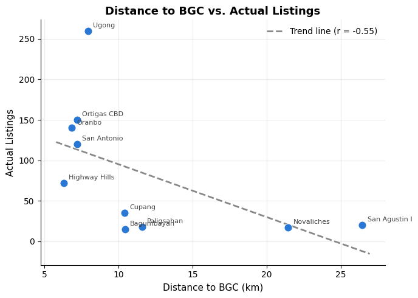

```
r = -0.548, slope = -6.52, intercept = 160.20
```

```python
# %% Graph 1: Distance to BGC vs. Listings
plot_correlation(
    bgc_dist, listings, areas,
    xlabel="Distance to BGC (km)",
    title="Distance to BGC vs. Actual Listings",
    color="#2a78d6",
)
```

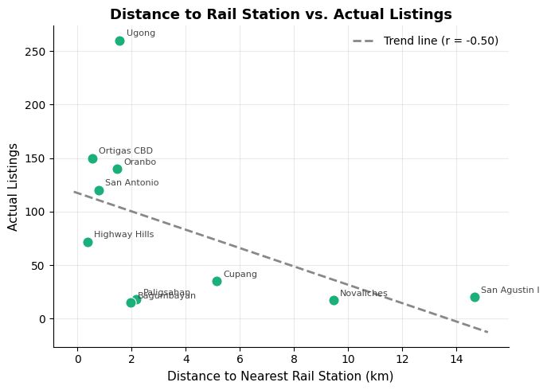

```
r = -0.495, slope = -8.57, intercept = 117.36
```

```python
# %% Graph 2: Distance to Rail Station vs. Listings
plot_correlation(
    station_dist, listings, areas,
    xlabel="Distance to Nearest Rail Station (km)",
    title="Distance to Rail Station vs. Actual Listings",
    color="#1baf7a",
)
```

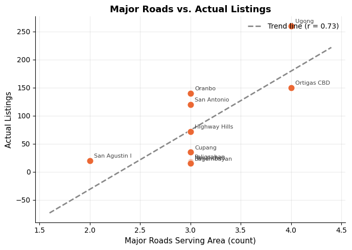

```
r = 0.732, slope = 105.28, intercept = -241.66
```

```python
# %% Graph 3: Major Roads vs. Listings
plot_correlation(
    roads, listings, areas,
    xlabel="Major Roads Serving Area (count)",
    title="Major Roads vs. Actual Listings",
    color="#eb6834",
    x_pad=0.4,
)
```